# L11_GPR_Sampling slides

## AERSP 597 - Machine Learning in Aerosapce Engineering

## Lecture 11, Gaussian Process Regression: Sampling

### Instructor: Daning Huang

## TODAY: Gaussian Process Regression - IV

- Design of computer experiments
- Latin hypercube sampling
- Low-discrepancy sequence

## Motivation

- Previously, we assume the training dataset is **given** to us, i.e. we do not take control of the data generation. The sample input may not be representative of the parameter space of interest.
- But in many cases, we want a **surrogate** of a computational model that is expensive to evaluate.
  - For example, a CFD or FEM model
  - But in this case, we can **specify** a set of inputs that populates the parameter space.
- The question then becomes how to choose inputs to best represent the parameter space, and build the ML model that approximates the input-output relation of interest.

> Differences between this lecture and the previous lecture.
> - Previously, the sampling focused on the approximation of a probabilistic distribution.
> - This time, the sampling is about the infilling of a space.

## Design of Experiments

- Full-factorial
  - For $d$ dimensions, divide each into $N$ intervals, and generate a $N^d$ grid.
  - Good for low-dimensions
- Variants
  - Central composite design: Factorial + Center + Axial
  - Box-Behnken, Plackett-Burman, etc.
  - See wikipedia
- Issues
  - Curse of dimensionality
  - Insufficient for complex functions

## Latin Hypercube Sampling

- For $d$ dimensions, divide each into $N$ intervals, and generate $N$ points.
  - No two points share the same interval in the same dimension.
  - "having N rooks on a chess board without threatening each other."
- Typical criteria
  - Center the points within the sampling intervals.
  - Maximize the minimum distance between points and place the point in a randomized location within its interval.
  - Maximize the minimum distance between points and center the point within its interval.
  - Minimize the maximum correlation coefficient.
- Issues
  - Sometimes not *orthogonal*, i.e. not sufficiently uniform.
  - Need multiple runs to obtain satisfactory sample distribution.

## Thinking about Sampling

What we want:

- Uniformly cover the parameter space
- Does not explode with dimensionality
- Randomness to avoid system bias
- Easy to generate (hopefully)

## Low-Discrepancy Sequence

It generates **quasirandom** numbers

### Four levels of randomness

- Eurandom (e.g. quantum random number)
  - Unpredictable
  - Uncorrelated (independent)
  - Uniform (unbiased)
- Pseudorandom (e.g. conventional random number)
  - Look like random, but *predictable*
  - Uncorrelated (independent)
  - Uniform (unbiased)
- **Quasirandom**
  - Does not look like random, but effectively random.
  - Uniform (unbiased)

> Nonrandom (e.g. Full Factorial Design)

```python
np.random.seed(1)  # Pseudorandom
np.random.rand()   # Always 0.417022004702574
```

```
0.417022004702574
```

### Discrepancy as Uniformity

- Definition for an interval
  - Difference between the fractions of samples and area.
  - A larger area should contain more samples. $$ D(a,b) = \left| \frac{\mathbf{Count}[a,b)^2}{\mathbf{Count}[0,1)^2} - \frac{\mathbf{Area}[a,b)^2}{\mathbf{Area}[1,0)^2} \right| $$
- This provides an index for the uniformity of the samples (over a unit space) $$ D=\max_{a,b} D(a,b) $$
- Simplified index, star discrepancy $$ D^*=\max_b D(0,b) $$

### One-dimension example

- Van der Corput sequence

  > 0.1, 0.2, 0.3, 0.4, 0.5, 0.6, 0.7, 0.8, 0.9, 0.01, 0.11, 0.21, 0.31, 0.41, 0.51, 0.61, 0.71, 0.81, 0.91, 0.02, 0.12, 0.22, 0.32, ...
- Works for other number bases, too. $$ n=\sum_{i=0}^{L-1} d_k(n)b^k \quad\Rightarrow\quad g_b(n)=\sum_{i=0}^{L-1} d_k(n)b^{-k-1} $$
- Extends to $d$ dimensions
  - Halton: The $n$th sample: $(g_{b_1}(n),\cdots,g_{b_d}(n))$
  - Hammersley: The $n$th sample: $(g_{b_1}(n),\cdots,g_{b_{d-1}}(n), n/N)$
  - where $b_1,\cdots,b_d$ are co-prime numbers

### Comparison of Sampling Methods

Over a unit square:

- Full factorial
- Uniformly random
- Latin hypercube
- LDS: Halton
- LDS: Hammersley
- LDS: Sobol

```
Mean: 1.890e-02, Std: 0.000e+00
```

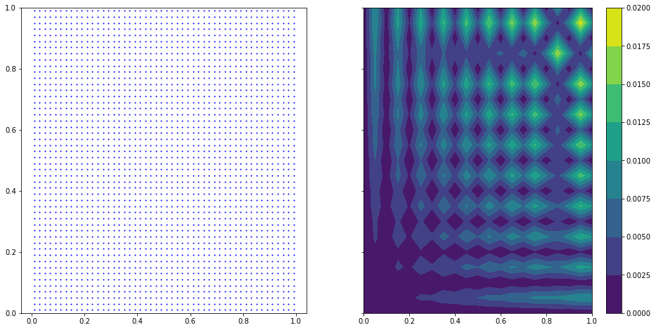

```python
s = runDisc(Grid, 2500, 21, 1)  # Deterministic, so running only once
pltDisc(s, 21)
```

```
Mean: 1.894e-02, Std: 5.344e-03
```

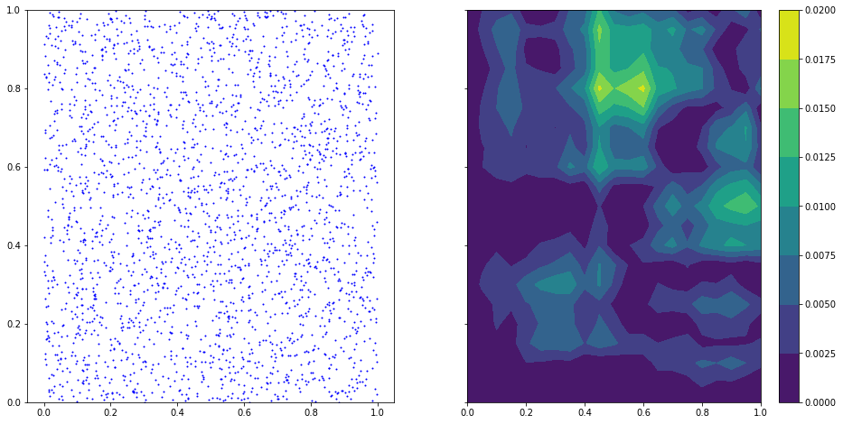

```python
s = runDisc(URand, 2500, 21, 10)
pltDisc(s, 21)
```

```
Mean: 9.690e-03, Std: 1.947e-03
```

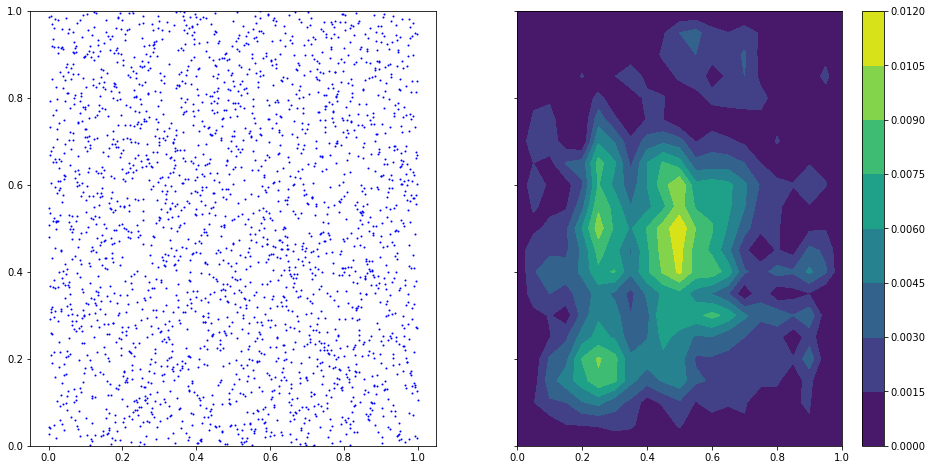

```python
s = runDisc(LHS, 2500, 21, 10)
pltDisc(s, 21)
```

```
Mean: 2.000e-03, Std: 0.000e+00
```

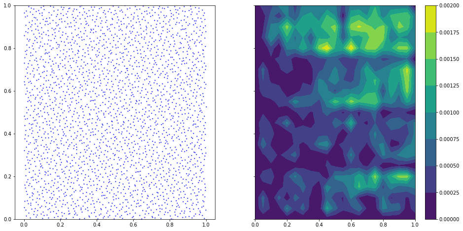

```python
s = runDisc(Halton, 2500, 21, 1)  # Deterministic, so running only once
pltDisc(s, 21)
```

```
Mean: 1.200e-03, Std: 0.000e+00
```

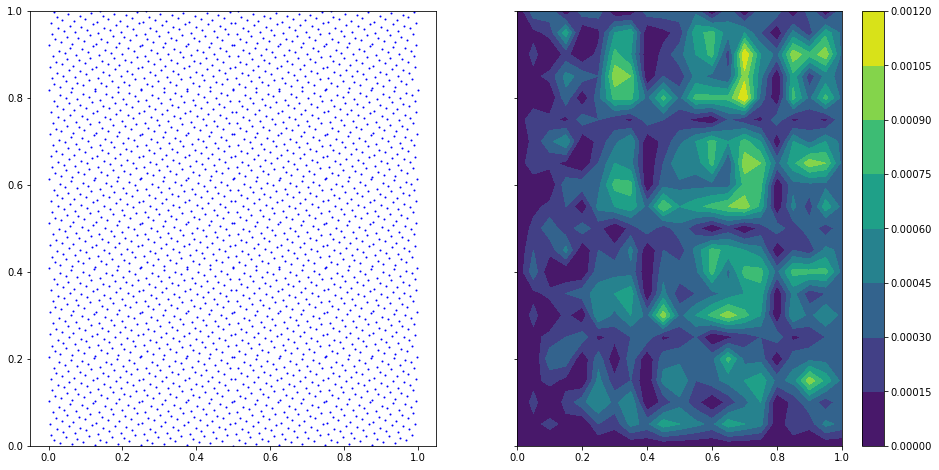

```python
s = runDisc(Hmsl, 2500, 21, 1)  # Deterministic, so running only once
pltDisc(s, 21)
```

```
Mean: 1.200e-03, Std: 0.000e+00
```

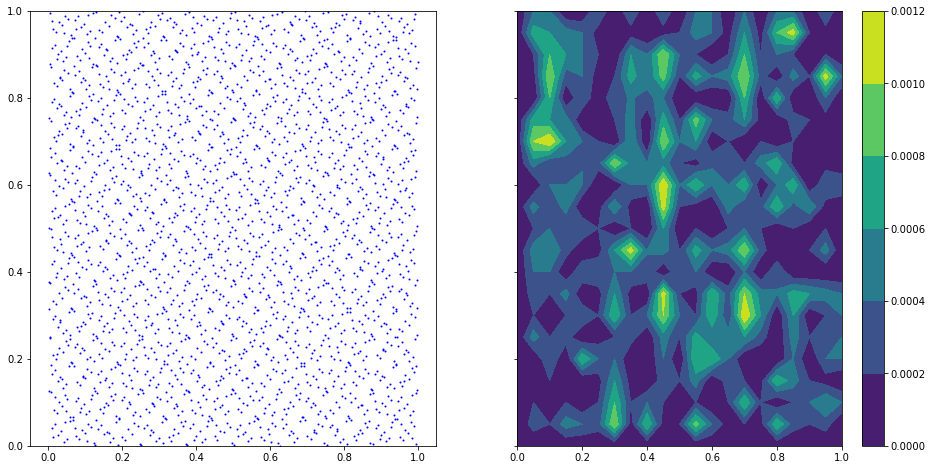

```python
s = runDisc(lambda N: Sobol(N,sk=10), 2500, 21, 1)  # Deterministic, so running only once
pltDisc(s, 21)
```

### Additional Benefits using LDS

Leads to quasi Monte Carlo:

- Monte Carlo using LDS samples
- Error in a $d$-dimensional space $$ \epsilon \sim \frac{\ln{N}^d}{N} $$
- In low-dimensions, better than regular Monte Carlo $$ \epsilon \sim \frac{\sqrt{N}}{N} $$

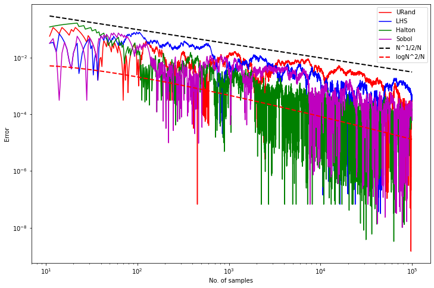

```python
lbls = ['URand', 'LHS', 'Halton', 'Sobol']
stys = ['r-', 'b-', 'g-', 'm-']
Ns = np.arange(11.0,N+1.0)
f = plt.figure(figsize=(12,8))
for _i in range(4):
    plt.loglog(Ns, R[_i], stys[_i], label=lbls[_i])
plt.loglog(Ns, 1/np.sqrt(Ns), 'k--', linewidth=2, label='N^1/2/N')
plt.loglog(Ns, 0.01*np.log(Ns)**2/Ns, 'r--', linewidth=2, label='logN^2/N')
plt.ylabel('Error')
plt.xlabel('No. of samples')
_=plt.legend()
```